# Identify co-expression modules

Sanjeeva

Nov 12, 2020

Samples info:

Samples are cardiac fibroblasts isolated from mice of different genotypes without injuries and that at different days after myocardial infarction. For all WT (genotype) samples, the sample size per each treament is 2. Genotype “Tcf21 KO”, treatment “7d MI” also has 2 samples. For “Tcf21 ko” with “4w MI” and the other genotype “Acta2 KO”, there is only 1 sample each. The details of the samples are provided in the table below.

|  |  | species | i7 | i5 | genotype | treatment | full name |
| --- | --- | --- | --- | --- | --- | --- | --- |
| C | C15 | Mus musculus | ATTACTCG | AGGCTATA | WT | uninjured | UNINJURY 6.23 |
| C | C16 | Mus musculus | GAATTCGT | TAAGATTA | WT | uninjured | UNINJURY 6.30 |
| C | C17 | Mus musculus | TCCGGAGA | AGGCTATA | WT | 3d MI | 3DMI 6.23 |
| C | C18 | Mus musculus | GAGATTCC | TCAGAGCC | WT | 3d MI | 3DMI 6.30 |
| C | C19 | Mus musculus | CGCTCATT | AGGATAGG | WT | 7d MI | 7DMI 6.23 |
| C | C20 | Mus musculus | ATTCAGAA | CTTCGCCT | WT | 7d MI | 7DMI 6.30 |
| C | C21 | Mus musculus | CTGAAGCT | TAAGATTA | Tcf21 ko | 7d MI | 242 TFC21KO MI7D |
| C | C22 | Mus musculus | CTGAAGCT | ACGTCCTG | WT | 2w MI | 2WMI #623 |
| C | C23 | Mus musculus | CGCTCATT | GCCTCTAT | WT | 2w MI | 2WMI 7.7 |
| C | C24 | Mus musculus | TCCGCGAA | GTCAGTAC | WT | 4w MI | 4W (5WMI) |
| C | C25 | Mus musculus | GAATTCGT | TCAGAGCC | WT | 4w MI | 4WMI #142 |
| C | C26 | Mus musculus | ATTCAGAA | AGGATAGG | Acta2 KO | 7d MI | ACTAKO 487 |
| C | C27 | Mus musculus | TAATGCGC | TAAGATTA | Tcf21 ko | 7d MI | 832 TCF21 KO 7D MI |
| C | C38 | Mus musculus | CTGAAGCT | CTTCGCCT | Tcf21 ko | 4w MI | 245 TCKF21KO 4W MI |

i7 - i7 Index Sequences (6 bp or 8 bp); i5 - Optional: i5 Index Sequence (6 bp or 8bp)

# Module loading

```r
library(WGCNA)
library(pheatmap)
library(grid)
library(flashClust)
library(rUtils)
# source('E:/users/javon/coding/github/Javon-WS/r/packages/utils/R/convMatIdx1to2.R')
# The following setting is important, do not omit.
options(stringsAsFactors = FALSE);
# Allow multi-threading within WGCNA. This helps speed up certain calculations.
# At present this call is necessary for the code to work.
# Any error here may be ignored but you may want to update WGCNA if you see one.
enableWGCNAThreads()
dataDir <- 'R:/projects/tissue-regen/data/mouse-cardiac-fibro/rna/expr/pooled/'

ana_dir <- 'R:/projects/tissue-regen/analysis/mouse-cardiac-fibro/rna/module/'

expr_data <- read.csv(file = paste0(dataDir, '/tpm_gene.csv'), stringsAsFactors = FALSE)
sample_info <- read.csv(file='https://raw.githubusercontent.com/ODU-CSM/functional-genomics/master/data-analysis/mouse-cadiac-fibro/rna/samples-info.md?token=AM4TEPP77XHKVZGFCZ655DC72KPUG')
```

# Data Info

First few rows of data:

|  | seqid | start | end | gene_symbol | gene_id | Uninjured_C15 | Uninjured_C16 | D3_C17 | D3_C18 | D7_C20 | W2_C22 | W2_C23 | W4_C24 | W4_C25 | D7_C26 |
| --- | --- | --- | --- | --- | --- | --- | --- | --- | --- | --- | --- | --- | --- | --- | --- |
| 1 | 1 | 3073253 | 3074322 | 4933401J01Rik | ENSMUSG00000102693 | 0.00 | 0.00 | 0.00 | 0.00 | 0.00 | 0.00 | 0.00 | 0.00 | 0.00 | 0.00 |
| 2 | 1 | 3205901 | 3671498 | Xkr4 | ENSMUSG00000051951 | 0.02 | 0.05 | 0.31 | 0.00 | 0.59 | 0.00 | 0.35 | 0.03 | 0.19 | 0.82 |
| 3 | 1 | 3365731 | 3368549 | Gm37180 | ENSMUSG00000103377 | 0.09 | 0.60 | 0.06 | 1.55 | 0.41 | 1.79 | 0.54 | 0.86 | 0.00 | 0.00 |
| 4 | 1 | 3375556 | 3377788 | Gm37363 | ENSMUSG00000104017 | 1.15 | 1.07 | 0.15 | 2.66 | 0.60 | 1.42 | 1.35 | 0.51 | 1.61 | 0.00 |
| 5 | 1 | 3464977 | 3467285 | Gm37686 | ENSMUSG00000103025 | 0.00 | 0.85 | 0.00 | 0.00 | 4.74 | 0.00 | 0.37 | 0.00 | 1.42 | 1.52 |
| 6 | 1 | 3512451 | 3514507 | Gm37329 | ENSMUSG00000103201 | 0.00 | 0.00 | 0.04 | 0.00 | 0.00 | 0.00 | 0.00 | 0.00 | 0.00 | 0.00 |

### Number of rows: 25746

### Number of columns: 15

```r
names(expr_data)[6:ncol(expr_data)]
```

```
##  [1] "Uninjured_C15" "Uninjured_C16" "D3_C17"        "D3_C18"
##  [5] "D7_C20"        "W2_C22"        "W2_C23"        "W4_C24"
##  [9] "W4_C25"        "D7_C26"
```

```r
data_use <- expr_data[, c(4, 6:ncol(expr_data))]


uninjured <- c("Uninjured_C15", "Uninjured_C16")
d3 <- c("D3_C17", "D3_C18")
d7 <- c("D7_C20", "D7_C26")
w2 <- c("W2_C22", "W2_C23")
w4 <- c("W4_C24", "W4_C25")
```

```r
# remove genes that had no expression at any stage
data_use <- data_use[apply(data_use[, 2:ncol(data_use)], 1,
                           function(x){if(length(which(x == 0)) == length(x)) return(FALSE) else return(TRUE)}), ] # 19040, no gene is removed from this

# thresholds used to filter out low expressed gene
min_fpkm <- 0.1 # minimum of FPKM
min_nCell <- 1 # minimum of number cells in which the expression of a gene is at least min_fpkm
################################

keep <- apply(data_use[, 2:ncol(data_use)], 1,
              function(x){if(length(which(x >= min_fpkm)) < min_nCell) return(FALSE) else return(TRUE)})
data_use <- data_use[keep, ]

# save the data for future use
# write.csv(data_use, file = paste0(ana_dir, '/data/module-gene.fpkm.csv'),
#           row.names = FALSE, quote = FALSE)

# Merge data from the same developmental stage
data_merged <- data.frame(gene = data_use$gene_symbol)
data_merged <- cbind(data_merged, uninjured = apply(data_use[, match(uninjured, names(data_use))], 1, mean))
data_merged <- cbind(data_merged, d3 = apply(data_use[, match(d3, names(data_use))], 1, mean))
data_merged <- cbind(data_merged, d7 = apply(data_use[, match(d7, names(data_use))], 1, mean))
data_merged <- cbind(data_merged, w2 = apply(data_use[, match(w2, names(data_use))], 1, mean))
data_merged <- cbind(data_merged, w4 = apply(data_use[, match(w4, names(data_use))], 1, mean))
```

There are 541 genes with a FPKM over 0.1 in less than 1 cell(s). These genes were excluded from the subsequent analysis. The total number of remaining genes is 17713.

# Co-expressed gene modules

## Cluster analysis

```r
datMat <- t(data_use[, 2:ncol(data_use)])

# tom <- TOMsimilarity((0.5 + 0.5 * cor(datMat, use = 'p')) ^ 12)
# # The computation of tom takes a lot of time (over one hour)
# # So, here we save it once it is computed and loaded later for quickly generating the pdf document.
# # Note, if data for computing tom is changned, it needs to be recomputed.
# save(tom, file = paste0(ana_dir, '/data/tom.RData'))

load(paste0(ana_dir, '/data/tom.RData'))

tree <- flashClust(as.dist(1 - tom), method = 'average')
unmergedLabels = cutreeDynamic(dendro = tree, distM = 1-tom,
        deepSplit = 2, cutHeight = NULL,
        minClusterSize = 30,
        pamRespectsDendro = FALSE );
unmergedColors = labels2colors(unmergedLabels)
```

The total number clusters (co-expresson modules) resulted from the hierarchial cluster analysis are 61. The distribution of the genes accross these clusters are:

```r
table(unmergedColors)
```

```
## unmergedColors
##   antiquewhite4         bisque4           black            blue           brown
##              51              84             780             918             916
##          brown4          coral1            cyan       darkgreen        darkgrey
##              85              52             529             256             207
##     darkmagenta  darkolivegreen      darkorange     darkorange2         darkred
##             119             133             183              86             304
##   darkseagreen4   darkslateblue   darkturquoise     floralwhite           green
##              54              80             251              87             831
##     greenyellow          grey60       honeydew1           ivory  lavenderblush3
##             666             388              56              95              56
##       lightcyan      lightcyan1      lightgreen      lightpink4 lightsteelblue1
##             396              97             363              62              98
##     lightyellow         magenta          maroon   mediumpurple3    midnightblue
##             314             720              63             103             469
##    navajowhite2          orange      orangered4   paleturquoise  palevioletred3
##              64             207             107             135              66
##            pink           plum1           plum2          purple             red
##             757             107              76             681             780
##       royalblue     saddlebrown          salmon         salmon4         sienna3
##             311             154             542              68             118
##         skyblue        skyblue3       steelblue             tan        thistle1
##             158             109             151             649              68
##        thistle2       turquoise          violet           white          yellow
##              73            1096             134             172             866
##     yellowgreen
##             112
```

The below is the dendrogram (figures/md-dg-1.pdf) from the cluster analyis:

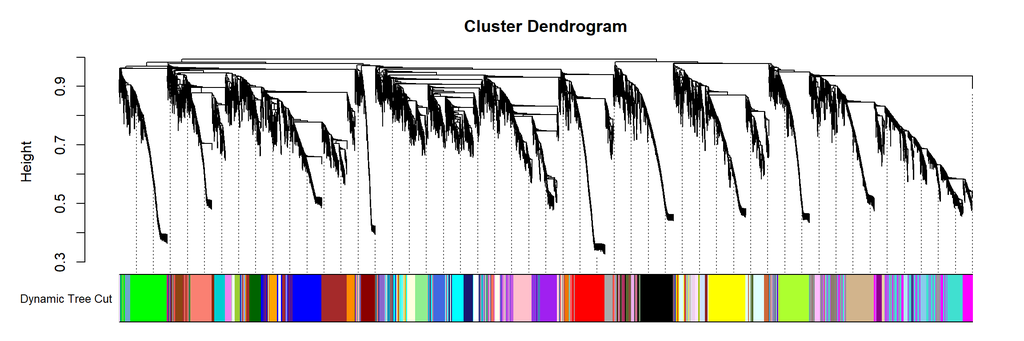

```r
plotDendroAndColors(tree, unmergedColors, "Dynamic Tree Cut",
        dendroLabels = FALSE, hang = 0.03,
        addGuide = TRUE, guideHang = 0.05)
```

```r
# compute module eigengenes
ME <- moduleEigengenes(datMat, unmergedColors)
cor_ME <- cor(ME$eigengenes, use = 'p') # correlation among modules
# merge highly correlated modules
merge = mergeCloseModules(datMat, unmergedLabels, MEs = NULL, cutHeight = 0.5, verbose = 3)
# Numeric module labels
moduleLabels = merge$colors;
# Convert labels to colors
moduleColors = labels2colors(moduleLabels)
# create the (label, color) map
unique_lbls <- unique(moduleLabels)
lbl_clr_map <- data.frame(label = unique_lbls, color = rep('', length(unique_lbls)))
for (iLbl in 1:length(unique_lbls)) {
    lbl_clr_map$color[iLbl] <- moduleColors[moduleLabels == unique_lbls[iLbl]][1]
}
# save module gene list
for (lbl in unique_lbls) {
    write.table(data_use$gene_symbol[moduleLabels == lbl],
            file = paste0(ana_dir, '/gene_list/M', lbl, '.txt'),
            row.names = FALSE, col.names = FALSE, sep = ' ', quote = FALSE)
}
```